# Tsubpartitioning_Maize_Roots_N

Author

Katja Holzhauser, Agronomy and Crop Science Group, Kiel University

Published

September 7, 2026

# 1 Summary

Module for dry matter and nitrogen partitioning of silage maize. Authors: Katja Holzhauser, Josephine Bukowiecki, Babette Wienforth, Henning Kage & Crop Science and Agronomy Group, Kiel University Last edited: 14.08.2026 Parts of the module are published in: References Holzhauser, K., Wienforth, B.M., Komainda, M., Herrmann, A., Zimmermann, I. & Dippold, M.A. et al. (2026) HUME-Maize: modelling silage maize yield formation across genotypes and scales. The Journal of Agricultural Science, 164, e34. Available from: https://doi.org/10.1017/S0021859626100719. Holzhauser, K. (2025) Cover Crops for Sustainable Silage-Maize Production: Enhancing Resource Use Efficiency through Modelling and Remote Sensing (Doctoral dissertation). Christian-Albrechts-Universität zu Kiel: Kiel Available from: https://macau.uni-kiel.de/receive/macau_mods_00006346. Wienforth, B. (2011) Cropping systems for biomethane production: a simulation based analysis of yield, yield potential and resource use efficiency (Doctoral dissertation). Christian-Albrechts-Universität zu Kiel

## 1.1 Descendence

The class Tsubpartitioning_Maize_Roots_N has the following ancestor classes shown in Table 1.

Table 1: Ancestor classes of Tsubpartitioning_Maize_Roots_N

| AncestorClass | Namespace |
| --- | --- |
| Tsubpartitioning_Maize | Usubpartitioning_Maize |
| TAbstractPlant | UAbstractPlant |
| TSubmodel | UMod |
| TGraphicControl | Vcl.Controls |
| TControl | Vcl.Controls |
| TComponent | System.Classes |
| TPersistent | System.Classes |
| TObject | System |

TRUE

# 2 Scientific Background

## 2.1 Dry matter partitioning

### 2.1.1 Datasets for Calibration and Evaluation

The model was evaluated with data of set 7-14. All field trials were conducted in 2021 and 2022. The trials providing dataset 7, 8, 11 and 12 were conducted at the experimental farm Hohenschulen (site A), but differed in the sowing date and the year of cultivation. The field trials for dataset 9 and 13 were located in the Northwest of Germany at the experimental farm Wehnen of the Agricultural Chamber of Lower Saxony and coordinated by the University of Göttingen (site C). Dataset 10 and 14 were compiled by field trials at Bad Hersfeld in Central Germany, managed by the Hessen department of agriculture (site D). In addition to climatic differences, soil types of location C and D were sand and sandy silt, respectively. The field trials of datasets 7, 9, 10, 11, 13 and 14 were conducted within a research project focussing on the nitrogen use efficiency of maize (Table 2). The N levels chosen for the present study were 180, 240 and 300 kg N ha<sup>-1</sup>, to ensure sufficient N supply. Mid-early maturity groups were selected for evaluation datasets as well (KWS Gunnario: 7,9,10,11,13,14; KWS Stefano: 8, 12).

Table 2: Datasets used for calibration and evaluation. The datasets differ in their location (Site A: Hohenschulen, Site B: Karkendam, Site C: Wehnen, Site D: Bad Hersfeld), soil type, trial year and sowing dates. Temperature is averaged and precipitation is summed up over the growing season (sowing till harvest date).

Datasets used for calibration and evaluation. The datasets differ in their location (Site A: Hohenschulen, Site B: Karkendam, Site C: Wehnen, Site D: Bad Hersfeld), soil type, trial year and sowing dates. Temperature is averaged and precipitation is summed up over the growing season (sowing till harvest date).

| Data Use | Dataset | Site | Geographical Position | Soil Type | Trial Year | Sowing Date | Temperature [°C] | Precipitation [mm] |
| --- | --- | --- | --- | --- | --- | --- | --- | --- |
| Calibration | 1 | A | 54.18°N, 9.58°E | Sandy loam | 2007 | 2007/04/19 | 14.8 | 496.5 |
| Calibration | 2 | A | 54.18°N, 9.58°E | Sandy loam | 2007 | 2007/05/15 | 15.4 | 452.4 |
| Calibration | 3 | B | 53.55°N, 9.56°E | Sand | 2007 | 2007/04/20 | 15.1 | 520.7 |
| Calibration | 4 | A | 54.18°N, 9.58°E | Sandy loam | 2008 | 2008/04/24 | 14.5 | 370.6 |
| Calibration | 5 | A | 54.18°N, 9.58°E | Sandy loam | 2008 | 2008/04/30 | 14.6 | 357.9 |
| Calibration | 6 | B | 53.55°N, 9.56°E | Sand | 2008 | 2008/04/28 | 15.1 | 371.4 |
| Evaluation | 7 | A | 54.18°N, 9.58°E | Sandy loam | 2021 | 2021/04/28 | 15.4 | 461.8 |
| Evaluation | 8 | A | 54.18°N, 9.58°E | Sandy loam | 2021 | 2021/05/20 | 16.0 | 389.7 |
| Evaluation | 9 | C | 51.49°N, 9.93°E | Sand | 2021 | 2021/05/01 | 15.5 | 524.3 |
| Evaluation | 10 | D | 51.59°N, 9.85°E | Sandy silt | 2021 | 2021/05/31 | 15.6 | 322.7 |
| Evaluation | 11 | A | 54.18°N, 9.58°E | Sandy loam | 2022 | 2022/04/28 | 16.2 | 238.7 |
| Evaluation | 12 | A | 54.18°N, 9.58°E | Sandy loam | 2022 | 2022/04/29 | 15.7 | 273.5 |
| Evaluation | 13 | C | 51.49°N, 9.93°E | Sand | 2022 | 2022/05/02 | 17.3 | 182.5 |
| Evaluation | 14 | D | 51.59°N, 9.85°E | Sandy silt | 2022 | 2022/05/09 | 18.4 | 132.5 |

### 2.1.2 Modelling DM partitioning and GAI expansion

In the first step, the daily produced $DM_{\text{total}}$$DM_{\text{total}}$ is divided into shoot dry matter ($DM_{\text{shoot}}$) and root dry matter ($DM_{\text{root}}$ or $DM_{\text{fineroot}}$, Eq. 1):

$$\mathrm{DM}_{\mathrm{total}} = \mathrm{DM}_{\mathrm{root}} + \mathrm{DM}_{\mathrm{shoot}} \tag{1}$$

$$\frac{\mathrm{dDM}_{\mathrm{total}}}{\mathrm{dt}} = \frac{\mathrm{dDM}_{\mathrm{root}}}{\mathrm{dt}} + \frac{\mathrm{dDM}_{\mathrm{shoot}}}{\mathrm{dt}} \tag{2}$$

The increase of $DM_{\text{root}}$ through the season is determined by the allocation coefficient ($AC_{\text{root}}$), calculated according to Yang et al. (2004) , including a upper limit of root growth shortly after silking (DSstop Eq. 3).

$$\mathrm{AC}_{\mathrm{root}} = \mathrm{ACE}_{\mathrm{root}} - \mathrm{DS} \cdot \mathrm{ACE}_{\mathrm{root}} \cdot \mathrm{DS}_{\mathrm{stop}} \tag{3}$$

$$\frac{\mathrm{dDM}_{\mathrm{root}}}{\mathrm{dt}} = \frac{\mathrm{dDM}_{\mathrm{total}}}{\mathrm{dt}} \cdot \mathrm{AC}_{\mathrm{root}} \tag{4}$$

The resulting proportion of $DM_{/text{root}}$ ($AC_{\text{root}}$) will be substracted, when computing the daily growth of $DM_{\text{shoot}}$:

$$\frac{\mathrm{dDM}_{\mathrm{shoot}}}{\mathrm{dt}} = \frac{\mathrm{dDM}_{\mathrm{total}}}{\mathrm{dt}} \cdot (1 - \mathrm{AC}_{\mathrm{root}}) \tag{5}$$

$DM_{\text{shoot}}$ is the sum of the organs leaf, stem and cobs (reproductive parts including tassel and husk)

$$\mathrm{DM}_{\mathrm{shoot}} = \mathrm{DM}_{\mathrm{leaf}} + \mathrm{DM}_{\mathrm{stem}} + \mathrm{DM}_{\mathrm{cob}} \tag{6}$$

$$\frac{\mathrm{dDM}_{\mathrm{shoot}}}{\mathrm{dt}} = \frac{\mathrm{dDM}_{\mathrm{leaf}}}{\mathrm{dt}} + \frac{\mathrm{dDM}_{\mathrm{stem}}}{\mathrm{dt}} + \frac{\mathrm{dDM}_{\mathrm{cob}}}{\mathrm{dt}} \tag{7}$$

$DM_{\text{shoot}}$ is further distributed between the leaf dry matter ($DM_{\text{leaf}}$), stem dry matter ($DM_{\text{stem}}$) and cob dry matter ($DM_{\text{cob}}$) by dry matter allocation factors $f_{\text{leaf}}$ and fcob. These factors describe the growth of the leaf and cob fractions over the numeric development stages, named XStage (translated BBCH stages, for further information see TMaizeDevelopment):

$$\frac{\mathrm{dDM}_{\mathrm{leaf}}}{\mathrm{dt}} = \frac{\mathrm{dDM}_{\mathrm{shoot}}}{\mathrm{dt}} \cdot f_{\mathrm{leaf}} \tag{8}$$

$$f_{\mathrm{leaf}} =
\begin{cases}
X_{\mathrm{Stage}} \cdot g + h & \text{if } X_{\mathrm{Stage}} > 1 \\
\mathrm{decay}_a \cdot X_{\mathrm{Stage}}^{\mathrm{decay}_b} & \text{if } \mathrm{GAI} > \mathrm{GAI}_{\mathrm{max}}
\end{cases} \tag{9}$$

The $f_{\text{leaf}}$ [-] is assumed to decrease across the XStages starting at emergence, described by the regression parameters g [-] and h [-]. Due to translocation processes from leaf to stem and cob, $DM_{\text{leaf}}$ [g m<sup>-2</sup>] is assumed to turn negative after silking (XStage = 3) or if the maximum GAI (GAImax, m<sup>2</sup> m<sup>-2</sup>) has been reached.

$$\frac{\mathrm{dDM}_{\mathrm{cob}}}{\mathrm{dt}} = \frac{\mathrm{dDM}_{\mathrm{shoot}}}{\mathrm{dt}} \cdot (1 - f_{\mathrm{cob}}) \tag{10}$$

$$f_{\mathrm{cob}} =
\begin{cases}
X_{\mathrm{Stage}} \cdot f_{\mathrm{cob,steig}} + f_{\mathrm{cob,ini}} & \text{if } \frac{\mathrm{DM}_{\mathrm{stem}}}{\mathrm{DM}_{\mathrm{shoot}}} > f_{\mathrm{stem,min}} \\
1 & \text{if } \frac{\mathrm{DM}_{\mathrm{stem}}}{\mathrm{DM}_{\mathrm{shoot}}} \leq f_{\mathrm{stem,min}}
\end{cases} \tag{11}$$

$$\frac{\mathrm{dDM}_{\mathrm{stem}}}{\mathrm{dt}} = \frac{\mathrm{dDM}_{\mathrm{shoot}}}{\mathrm{dt}} \cdot (1 - f_{\mathrm{leaf}}) \cdot (1 - f_{\mathrm{cob}}) \tag{12}$$

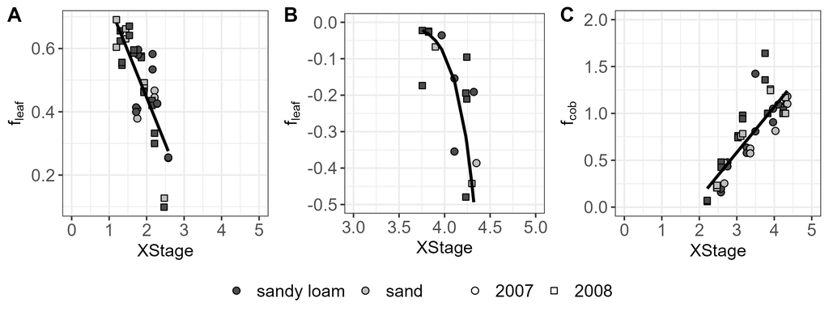

The GAI expansion and its growth rate are calculated as the sum of its compartments (LAI, SAI, Eq. 13) and their growth rates (Eq. 14), respectively.

$$\mathrm{GAI} = \mathrm{LAI} + \mathrm{SAI} \tag{13}$$

$$\frac{\mathrm{dGAI}}{\mathrm{dt}} = \frac{\mathrm{dLAI}}{\mathrm{dt}} + \frac{\mathrm{dSAI}}{\mathrm{dt}} \tag{14}$$

In many crop growth models, canopy development is represented using a constant SLA (option: SLAconst). In contrast, the present approach applies an allometric formulation in which SLA dynamically declines with increasing LAI, thereby accounting for self-shading and structural changes within the canopy (Ratjen and Kage (2013)). Growth rate of LAI is the product of the specific leaf area (SLA) and DMleaf. Thereby, SLA [m<sup>2</sup> g<sup>-1</sup>] is assumed to be the negative exponential function of LAI [m<sup>2</sup> m<sup>-2</sup>].

$$\frac{\mathrm{dLAI}}{\mathrm{dt}} = \mathrm{SLA} \cdot \frac{\mathrm{dDM}_{\mathrm{leaf}}}{\mathrm{dt}} \tag{15}$$

$$\mathrm{SLA} =
\begin{cases}
\mathrm{SLA}_{\mathrm{ini}} & \text{if } \mathrm{SLA} \geq \mathrm{SLA}_{\mathrm{ini}} \\
\mathrm{SLA}_a \cdot (\mathrm{LAI} - \mathrm{SLA}_b) & \text{if } \mathrm{SLA}_{\mathrm{ini}} > \mathrm{SLA} > \mathrm{SLA}_{\mathrm{min}} \\
\mathrm{SLA}_{\mathrm{min}} & \text{if } \mathrm{SLA} < \mathrm{SLA}_{\mathrm{min}}
\end{cases} \tag{16}$$

$$\frac{\mathrm{dLAI}}{\mathrm{dt}} = \mathrm{SLA}_a \cdot (\mathrm{LAI} - \mathrm{SLA}_b) - \mathrm{SLA}_a \cdot \mathrm{SLA}_b \cdot (\mathrm{LAI} - \mathrm{SLA}_b) \cdot \frac{\mathrm{dDM}_{\mathrm{leaf}}}{\mathrm{dt}} \tag{17}$$

The same applies for SAI [m^2^ g<sup>-1</sup>] and specific stem area:

$$\frac{\mathrm{dSAI}}{\mathrm{dt}} = \mathrm{SSA} \cdot \frac{\mathrm{dDM}_{\mathrm{stem}}}{\mathrm{dt}} \tag{18}$$

$$\mathrm{SSA} =
\begin{cases}
\mathrm{SSA}_{\mathrm{ini}} & \text{if } \mathrm{SSA} \geq \mathrm{SSA}_{\mathrm{ini}} \\
\mathrm{SSA}_a \cdot (\mathrm{SAI} - \mathrm{SSA}_b) & \text{if } \mathrm{SSA}_{\mathrm{ini}} > \mathrm{SSA} > \mathrm{SSA}_{\mathrm{min}} \\
\mathrm{SSA}_{\mathrm{min}} & \text{if } \mathrm{SSA} < \mathrm{SSA}_{\mathrm{min}}
\end{cases} \tag{19}$$

$$\frac{\mathrm{dSAI}}{\mathrm{dt}} = \mathrm{SSA}_a \cdot (\mathrm{SAI} - \mathrm{SSA}_b) - \mathrm{SSA}_a \cdot \mathrm{SSA}_b \cdot (\mathrm{SAI} - \mathrm{SSA}_b) \cdot \frac{\mathrm{dDM}_{\mathrm{stem}}}{\mathrm{dt}} \tag{20}$$

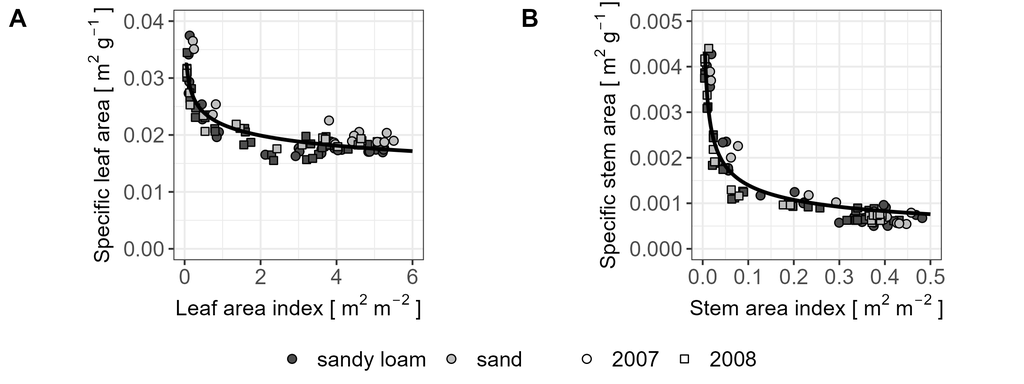

Figure 2: Calibration of model parameters for A: specific leaf area (SLA) and B: specific stem area (SSA), assuming, that both, SLA and SSA are decreasing with increasing leaf area index (LAI) and stem area index (SAI), respectively. SLA and SSA are restricted by an upper and a lower limit. Depicted are the different soil types (sandy loam, sand) and trial years (2007, 2008).

The proportion of senescent leaf area is depicted by the factor $f_{\text{sen}}$, increasing exponentially from the time of silking (XStage3). Parameters for $f_{\text{sen}}$ computation are $sen_a$, $sen_b$. Thereby, it is assumed that the ratio of the measured GAI values towards the highest measured GAI is the proportion of senescent leaf area.

$$\mathrm{GAI} = (1 - f_{\mathrm{sen}}) \cdot \mathrm{GAI}^* \tag{21}$$

$$f_{\mathrm{sen}} = \mathrm{sen}_a \cdot X_{\mathrm{Stage}}^{\mathrm{sen}_b} \tag{22}$$

Crop height is calculated in dependency to $DM_{\text{shoot}}$, fitted with data from a multiannual field trial (NeffMaize):

$$\mathrm{CropHeight} = \mathrm{height}_a + \mathrm{DM}_{\mathrm{shoot}} \cdot \mathrm{height}_b - \mathrm{height}_c \cdot \left( \mathrm{DM}_{\mathrm{shoot}} \right)^2 \tag{23}$$

### 2.1.3 Results of calibration and evaluation

Table 3: Results of model evaluation and calibration (in brackets) for dry matter partitioning into plant organs and the derived green area indices ($DM_{\text{leaf}}$, $DM_{\text{stem}}$, $DM_{\text{cob}}$, GAI, LAI, SAI) and of crop height. Performance was assessed with slope and intercept of the regression between measured and simulated data, R² and root mean square error (RMSE). n is the number of measurements.

Results of model evaluation and calibration (in brackets) for dry matter partitioning into plant organs and the derived green area indices ($DM_{\text{leaf}}$, $DM_{\text{stem}}$, $DM_{\text{cob}}$, GAI, LAI, SAI) and of crop height. Performance was assessed with slope and intercept of the regression between measured and simulated data, R² and root mean square error (RMSE). n is the number of measurements.

| Variable | Einheit | Steigung (Slope) | Achsenabschnitt (Intercept) | R² | n | RMSE |
| --- | --- | --- | --- | --- | --- | --- |
| $\mathrm{DM}_{\mathrm{leaf}}$ | [g m⁻²] | 0.83 (0.89) | 27.17 (-5.70) | 0.44 (0.82) | 33 (83) | 78.21 (53.94) |
| $\mathrm{DM}_{\mathrm{stem}}$ | [g m⁻²] | 1.65 (1.00) | -105.75 (-31.30) | 0.83 (0.92) | 34 (83) | 217.9 (85.04) |
| $\mathrm{DM}_{\mathrm{cob}}$ | [g m⁻²] | 0.98 (1.04) | -41.47 (61.81) | 0.91 (0.83) | 22 (43) | 173.61 (206.07) |
| $\mathrm{GAI}$ | [-] | 0.85 (0.92) | 0.5 (0.08) | 0.63 (0.73) | 212 (81) | 1.18 (1.08) |
| $\mathrm{LAI}$ | [-] | 0.85 (0.90) | 0.12 (-0.11) | 0.50 (0.80) | 30 (81) | 1.27 (0.98) |
| $\mathrm{SAI}$ | [-] | 0.94 (0.92) | 0.03 (-0.01) | 0.56 (0.92) | 30 (81) | 0.10 (0.05) |
| $\mathrm{CropHeight}$ | [m] | 1.39 (0.88) | -0.51 (-0.20) | 0.97 (0.96) | 19 (111) | 0.43 (0.24) |

### 2.1.4 Hybrid specific adaptations

The baseline version of HUME-Maize is based on the dataset with the older hybrid KWS Ronaldinio. An analysis with regard to the necessity of hybrid-specific adaption was conducted for the parameters of dry matter partitioning component. Consequently, the parameters necessary for the calculation of the green area expansion ($SLA_a$, $SLA_b$, $SSA_a$, $SSA_b$), as well as those for leaf and cob growth ($f_{\text{leaf}}$, $f_{\text{cob}}$) were tested by linear regression with hybrid as factor. The SLA models were based on a nonlinear power-law relationship between SLA and LAI (Eq. 16, Eq. 19), which was linearized through logarithmic transformation to enable parameter estimation via ordinary linear regression:

$$\mathrm{log(SLA)\ ~\ log(LAI)\ *\ Hybrid} \tag{24}$$

Hybrid-specific differences in SLA were assessed by including the hybrid as an interaction term with log-transformed LAI. From the estimated coefficients were used to derive the hybrid-specific parameters $SLA_a$ and $SLA_b$, by back-transforming the intercepts and slopes. This allowed for the estimation of distinct allometric scaling parameters for each hybrid. The same approach was applied analogously to model the relationship between SSA and SAI.

Table 4: Hybrid-specific parameterisation of dry matter partitioning variables – including specific leaf and stem area (SLA, SSA), leaf and cob growth ($f_{\text{leaf}}$, $f_{\text{cob}}$). The table provides hybrid-specific equations for each variable, along with the p-values indicating the significance of hybrid-specific differences.

Hybrid-specific parameterisation of dry matter partitioning variables – including specific leaf and stem area (SLA, SSA), leaf and cob growth ($f_{\text{leaf}}$, $f_{\text{cob}}$). The table provides hybrid-specific equations for each variable, along with the p-values indicating the significance of hybrid-specific differences.

| Variable | Old Hybrid | New Hybrid | *p*-value |
| --- | --- | --- | --- |
| $\mathrm{SLA}$ | $0.023 \cdot \mathrm{LAI}^{-0.143}$ | $0.020 \cdot \mathrm{LAI}^{-0.132}$ | $<0.0001$ *** |
| $\mathrm{SSA}$ | $0.0005 \cdot \mathrm{SAI}^{-0.425}$ | $0.0004 \cdot \mathrm{SAI}^{-0.438}$ | $<0.0001$ *** |
| $f_{\mathrm{leaf}}$ | $1.0318 - 0.2934 \cdot X_{\mathrm{Stage}}$ | $0.714 - 0.165 \cdot X_{\mathrm{Stage}}$ | $0.00127$ ** |
| $f_{\mathrm{cob}}$ | $-1.095 + 0.569 \cdot X_{\mathrm{Stage}}$ | $-1.087 + 0.431 \cdot X_{\mathrm{Stage}}$ | $0.95502$ |

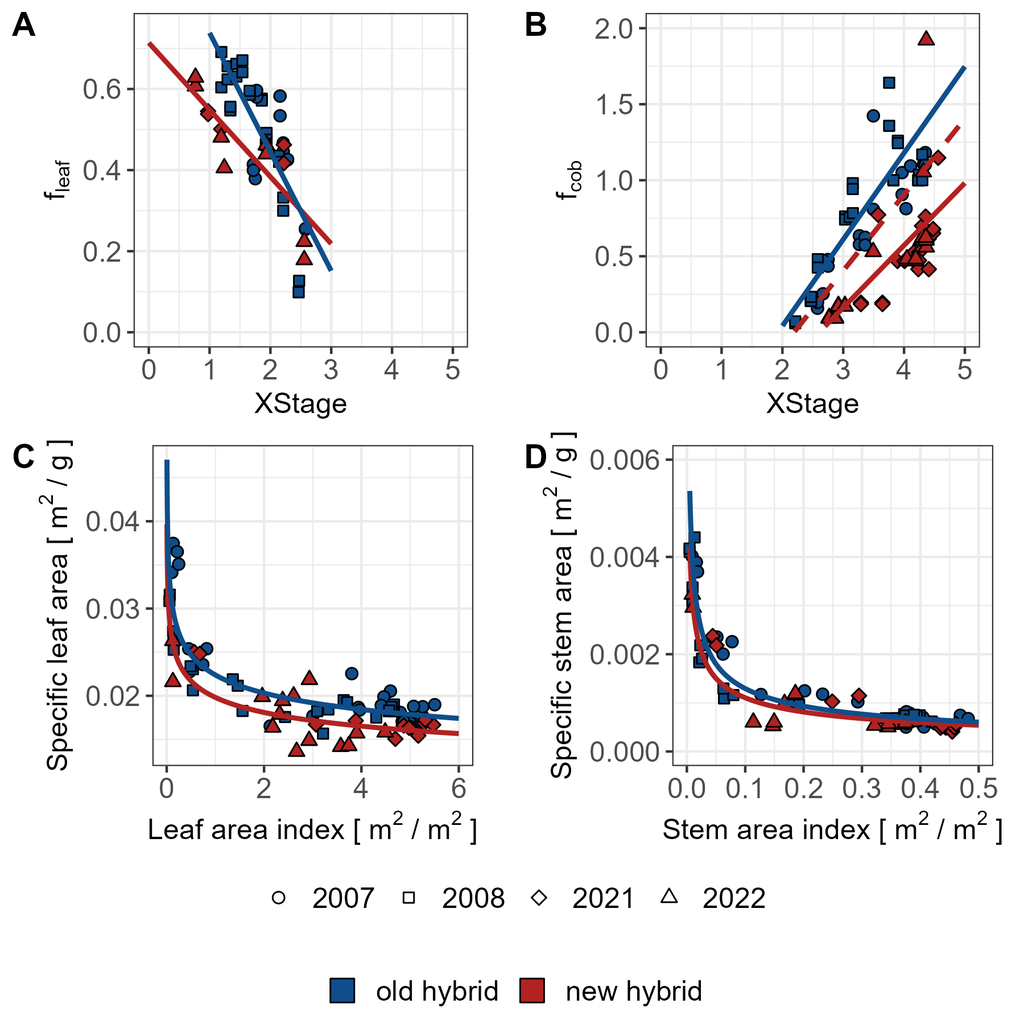

Figure 3: Panels A and B show the variables $f_{\text{leaf}}$ and $f_{\text{cob}}$, representing the dry matter growth rates of leaves and cobs, respectively, as functions of developmental stage (XStages). Dashed line in Panel B represents the model internal optimization of $f_{\text{cob}}$ development. Panels C and D illustrate specific leaf area (SLA) and specific stem area (SSA), which are modeled to decrease with increasing leaf area index (LAI) and stem area index (SAI), respectively. The data are presented for the old and the new hybrid across the trial years 2007, 2008, 2021, and 2022.

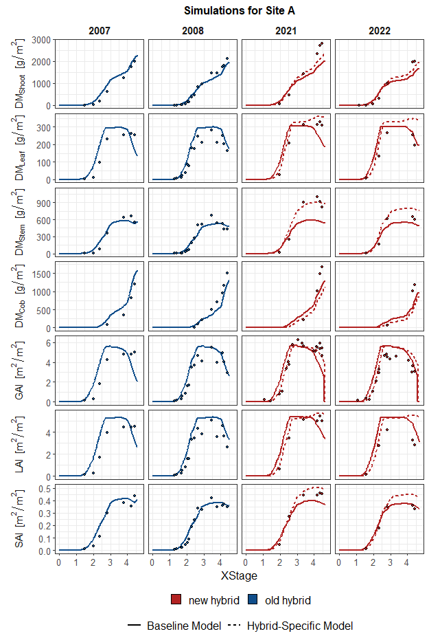

Figure 4: Simulated (lines) and observed (points) values of biomass growth ($DM_{\text{shoot}}$, $DM_{\text{leaf}}$, $DM_{\text{stem}}$, $DM_{\text{cob}}$; in g m<sup>-2</sup>) and green area expansion (GAI, LAI, SAI; in m^2^ m<sup>-2</sup>) across phenological stages (XStages) for the old (blue) and the new hybrid (red) for Site A across the two respective trial years. Depicted are the two model approaches, baseline model (solid line, parameterized by the old hybrid) and the hybrid specific model (dashed line, parameterized for both hybrids individually).

## 2.2 Nitrogen Dynamics and Critical N Concentration in Maize

During crop growth, plant nitrogen (N) concentration ($N_c$) typically declines as biomass accumulation increases and canopy structure changes. In particular, the expansion of structural tissues such as stems and reproductive organs contributes to a dilution of nitrogen (Caloin and Yu (1984)). Additionally, increasing canopy density leads to progressive self-shading, which results in an uneven distribution of nitrogen within the plant (Sinclair and Horie (1989); Bertheloot et al. (2008)). Leaves located in the upper canopy and best exposed to incoming radiation are the most photosynthetically active and therefore maintain the highest $N_c$ (Bertheloot et al. (2008)), whereas structural organs with limited photosynthetic function exhibit comparatively lower $N_c$ levels (Lemaire and Gastal (1997)).

For modelling approaches, it is not appropriate to consider N uptake at the whole plants level only, because N inputs not only affect the absolute amount of N in the crop, but can also cause distinct allocation patterns within the plant. Thus, total N uptake reduces after silking, while $N_c$ within the plant remains constant. However, distinct allocation processes result in a shift of $N_c$ from the leaves to the cob (Fig. 5), which leads to the senescence of leaf tissue and a reduction in the photosynthetic active green area. The application of N fertiliser can influence these processes: As depicted in Fig. 5 , higher N fertilisation levels lead to a generally higher N content in the leaves, while the lowest fertilisation level (0 kg ha<sup>-1</sup>) results in the lowest N content. Additionally, the decrease in N proportion is more pronounced with N limitations. Similar to the leaves, the N content in the stem decreases with increasing DM. Again, higher fertiliser levels have a positive effect on N partitioning to the stem, but the differences between N-levels are smaller than for the leaves. In contrast to the leaf and stem, the N proportion in the cob tends to increase with increasing DM, resulting from the translocation processes from vegetative organs to the generative organ. At the beginning of cob growth, cob’s N proportion is highest without N fertilization, indicating, a prioritisation of cob growth under N limitation.

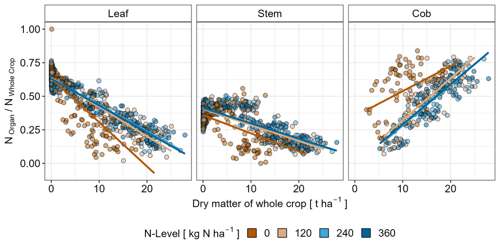

Figure 5: Relationship between the dry matter yield of the whole plant (t ha-1) and the proportion of N in different plant organs (leaf, stem, cob) relative to the total plant N

Critical nitrogen ($N_{\text{crit}}$) dilution curves are used to analyze the N status of crops, assuming a relationship between $N_c$$N_c$ and dry matter (DM) growth that determines the optimal N supply for the crop. These curves are based on the concept of $N_{\text{crit}}$ (Lemaire and Salette (1984)). $N_{\text{crit}}$ is defined as the minimum $N_c$ required to achieve maximum possible DM growth; beyond this point, additional N fertilization does not significantly increase DM growth (Ulrich (1952); Greenwood et al. (1991)). $N_{\text{crit}}$ dilution curves have been established for a range of crops, including wheat (Justes et al. (1994)), oilseed rape (Colnenne (1998)), barley (Zhao (2014)), rice (Ata-Ul-Karim et al. (2017)) , and sunflower (Debaeke et al. (2012)). For maize, the first dilution curve was proposed by Plenet and Lemaire (2000) and later extended to silage maturity by (Herrmann and Taube (2004)). However, a common feature across these studies is their focus on whole-plant N concentration, without explicitly accounting for organ-specific differences. Representing N uptake at the whole-plant level alone neglects the fact that N supply influences not only the total amount of N accumulated but also its allocation patterns among plant organs and their demands during the vegetation period (Bao et al. (2025)). Capturing such dynamics requires a more detailed, organ-resolved perspective.

It has been established that the N nutrition index (NNI) is a reliable metric for quantifying N stress. It can be derived from $N_{\text{crit}}$ dilution curves as the ratio between $N_c$ and $N_{\text{crit}}$. Modelling of the N status via whole-plant or leaf DM has been discussed in the literature (Ata-Ul-Karim et al. (2017); Zhao et al. (2017); Zhao et al. (2018); Sieling and Kage (2021)), as $N_c$ is highest in the photosynthetically active plant organ. In particular for the C4 plant maize, the assumption of a leaf-based NNI could serve as a more sensitive proxy of N stress (Sieling and Kage (2021)).

### 2.2.1 Critical N concentration

Determination of $N_{\text{crit}}$ was calculated according to Justes et al. (1994), via linear-plateau function for each available sampling date, further illustrated in Fig. 6 . To conduct that, a self-starting linear-plateau function (SSlinp) was used, describing a initial linear increase in DM with increasing $N_c$ up to a breakpoint (jp), beyond which DM reaches a plateau (and is not significantly increasing anymore). The breakpoints of the linear plateau models are the $N_{\text{crit}}$’s of the specific sampling dates, which equals the $N_c$ on which there is no significant increase in dry matter (Fig. 6 A). For some of the sampling dates, it was not possible to fit a linear-plateau. These sampling dates were not included into the further process of N dilution curve development.

$$N_c =
\begin{cases}
a \cdot \mathrm{DM}_{\mathrm{crit}}^b & \text{if } \mathrm{DM} < \mathrm{DM}_{\mathrm{crit}} \\
a \cdot \mathrm{DM}^b & \text{if } \mathrm{DM} \geq \mathrm{DM}_{\mathrm{crit}}
\end{cases} \tag{25}$$

With the first term, representing the $N_c$ for DM smaller than $DM_{\text{crit}}$ , illustrating the initial plateau of the function. Coefficient b represents the decrease of $N_c$ with DM growth. The parameters a, b and $DM_{\text{crit}}$ were fit with a non-linear least square model (nlsLM, Elzhov et al. (2022)).

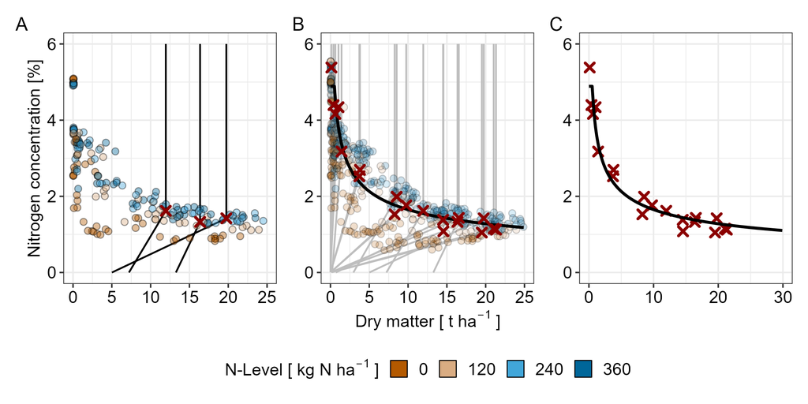

Figure 6: Example of the calculation of dilution curve for the whole plant. A: calculation of critical $N_c$ (%, red cross) of three example sampling dates (2007) via linear-plateau function. B: Calculation of critical $N_c$ for all available sampling dates (trial years: 2007, 2008, n=19). C: fitting N dilution curve through the calculated critical $N_c$ (N¬crit).

This process was calculated for the plant organs leaves and cobs (whereby panicles and husks were added to the cob fraction) as well as for the whole plant. For the stem fraction an exponential function was more suitable:

$$N_c =
\begin{cases}
a & \text{if } \mathrm{DM} < \mathrm{DM}_{\mathrm{crit}} \\
a \cdot \exp(\mathrm{DM} \cdot b) & \text{if } \mathrm{DM} \geq \mathrm{DM}_{\mathrm{crit}}
\end{cases} \tag{26}$$

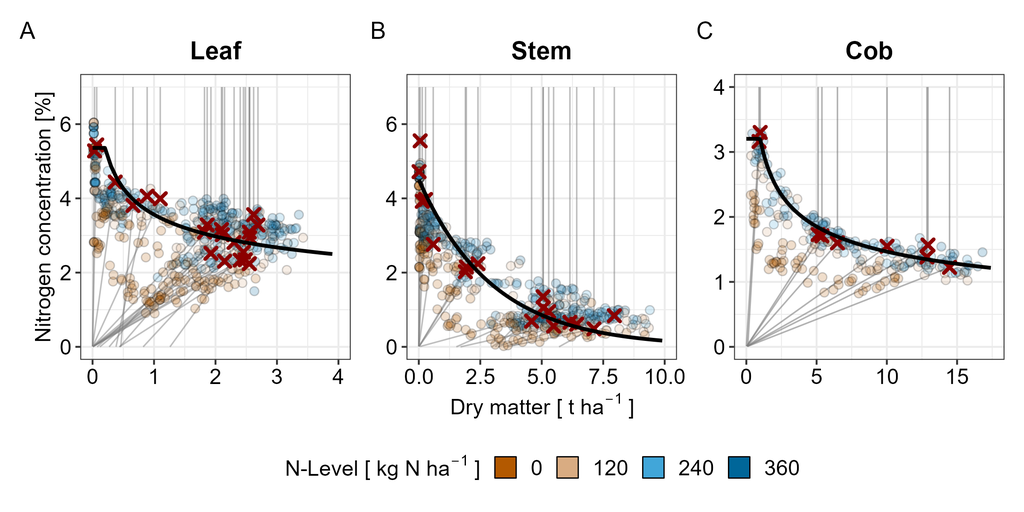

Figure 7: N dilution curves of organs (leaf, stem, cob, solid line) as the relation between N concentration (%) and dry matter (t ha-1) with datapoints coloured for specific N-levels and critical N concentrations (red cross). The latter was calculated via linear-plateau functions (grey lines, Justes et al. (1994)) for each available and computable sampling date.

Table 5: Formulas of N delution for whole plant assumption, as well as for organs leaf, stem and cob.

Formulas of N delution for whole plant assumption, as well as for organs leaf, stem and cob.

| Plant Part | DM_crit [t ha<sup>-1</sup>] | Nc [%] | Regression Model | n |
| --- | --- | --- | --- | --- |
| Whole plant | 0.52 | 4.90 | $\mathrm{3.85 \times DM^{-0.37}}$ | 19 |
| Leaf | 0.21 | 5.34 | $\mathrm{3.56 \times DM^{-0.26}}$ | 21 |
| Stem | 0.20 | 4.02 | $\mathrm{4.30 \times e^{-0.33 \times DM}}$ | 17 |
| Cob | 1.00 | 3.20 | $\mathrm{3.20 \times DM^{-0.34}}$ | 9 |

### 2.2.2 Model implementation of N partitioning

The component of plant N uptake was integrated to the HUME-Maize model. The previously described dilution curves have been implemented, allowing simulations either at the whole-plant level or with organ-specific N partitioning. For each daily timestep, the $N_{\text{crit}}$ is calculated based on the current DM increment ($DM_c$) of the regarded organ or the whole plant. $N_{\text{demand}}$ is then calculated as the difference between optimal and actual N content:

$$\mathrm{N\ Demand\ =\ }\left(\left(\ {\mathrm{DM}}_\mathrm{v}\mathrm{\ +\ } {\mathrm{DM}}_\mathrm{c}\ \right)\mathrm{\ *\ } \mathrm{N}_{\mathrm{crit}}\right)\ \mathrm{-\ }N_v | DM_c > 0 \tag{27}$$

Where $DM_v$ is the accumulated biomass, $DM_c$ the daily growth increment, and $N_v$ the current N content. The first term of Eq. 27 represents the optimal N content, and the difference to $N_v$ defines the N demand. In the organ-specific approach, demands are calculated for each organ and summed to total plant N demand. Actual N uptake is limited by soil N availability, which includes initial soil N, fertiliser input and mineralised N (Räbiger et al. (2020); Rothardt and Kage (2023)). A supply-demand ratio constrains uptake, ensuring that plant N acquisition does not exceed the available soil N:

$$\mathrm{Supply-Demand-Ratio\ (S:D)\ =\ }\frac{\mathrm{N\ Supply}}{\mathrm{N\ Demand}} \tag{28}$$

During later growth stages, when daily biomass change of leaves and stems becomes negative (DM_c < 0, DM-partitioning described in Holzhauser et al. (2026)), these organs act as N sources rather than sinks. Their $N_{\text{demand}}$ of these organs becomes negative and reflects N translocation:

$$\mathrm{N\ Demand\ =\ }{\mathrm{DM}}\mathrm{c}\mathrm{\ *\ }{\mathrm{Nc}}\mathrm{v}\mathrm{\ \ \ \ \ |\ }{\mathrm{DM}}\_\mathrm{c}\mathrm{\ <\ 0} \tag{29}$$

The surplus N is moved to a translocation pool (Ntrans). If the cob’s N demand exceeds the N supplied directly by the soil, the deficit is fulfilled using N from the Ntrans. This ensures that the N allocation to reproductive organs were met efficiently, even under soil N availability. Nitrogen nutrition index N stress is simulated via NNI, directly limiting DM production.

$$\mathrm{NNI\ =\ }\frac{\mathrm{N}_\mathrm{v}}{\left(\left(\mathrm{\ }{\mathrm{DM}}_\mathrm{v}\mathrm{\ +\ } {\mathrm{DM}}_\mathrm{c}\mathrm{\ } \right)\mathrm{\ *\ } \mathrm{N}_{\mathrm{crit}}\right)}\ \tag{30}$$

With the actual N amount Nv and the optimal N amount of the daily timestep, derived by the current DMv and the increment in DM ($DM_c$) multiplied by $N_{\text{crit}}$. In context of organ-specific approach NNI is calculated based on the DM, N and $N_{\text{crit}}$ of leaves. For the whole plant assumption, NNI is regularly calculated based on the whole plant biomass.

###Results

Results were calculated with similar mineralisation settings for each N-level, Site and Year (k_som_biom: 0.0003) following assumptions of Räbiger et al. (2020).

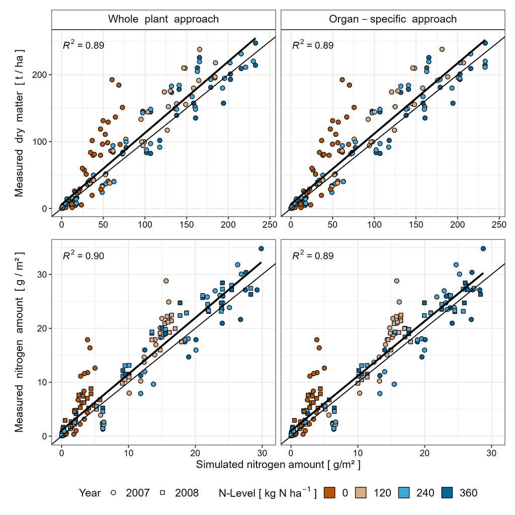

Figure 8: Measured vs. simulated dry matter (g/m²) and N uptake (g/m²) for both modelling approaches (dilution curve based on whole plant vs. Npartitioning via organ-specific dilution curves). Shown are datasets 1-6 () containing two sites (A and B), two years (2007-2008) and 4 N-levels and the respective R².

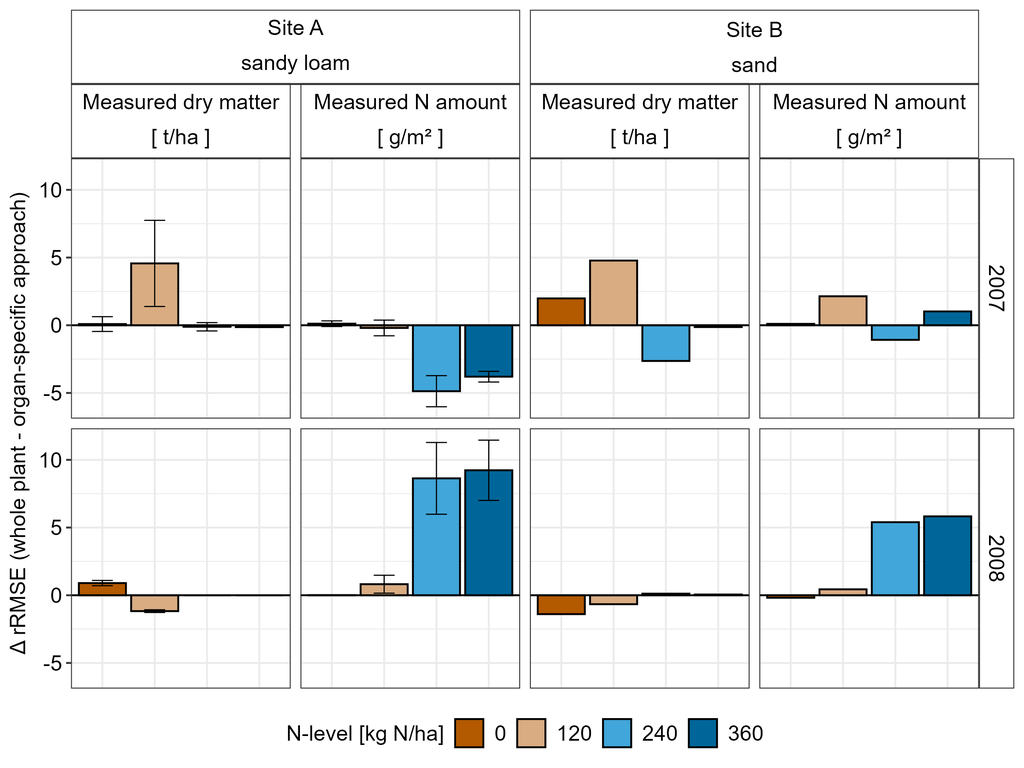

Figure 9: Comparison of the prediction performance of the two approaches as the difference in rRMSE (whole plant - organ-specific). A positive value is in favor of the organ-specific approach. Depicted are the relative RMSE of the two sites A and B of the datasets 1-6 (2007-2008), across the N-levels concerning N and dry matter simulation.

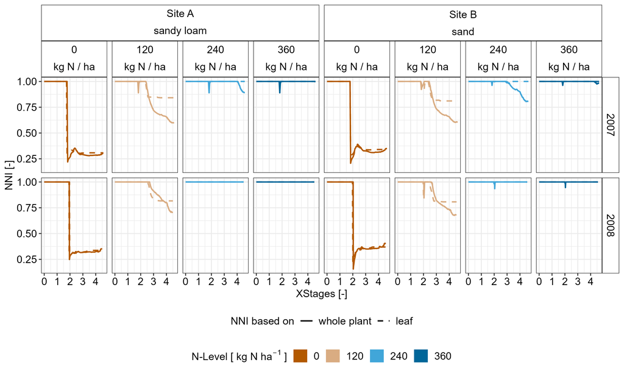

Figure 10: Simulated nitrogen nutrition index (NNI) based on whole plant N-content (solid) or leaf N content (dashed). The latter was computed by organ-specific dilution curves. Depicted are the Simulations for Site A and B of the datasets 1-6 (2007-2008) across the numeric development stages (XStages)

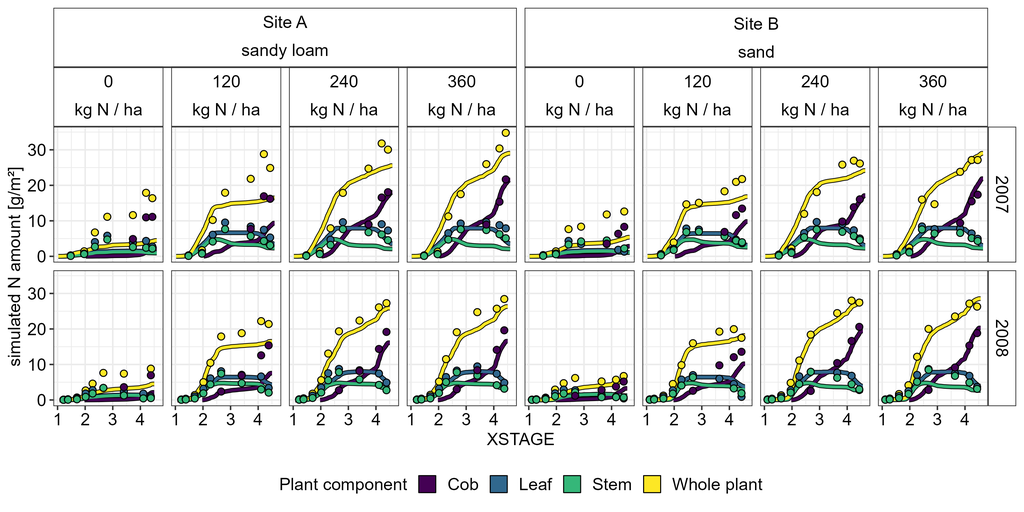

Figure 11: Simulation of N amount in plant components (Leaf, Stem, Cob and whole plant), with the organ-specific approach across the N levels. Depicted are the Simulations for Site A and B of the datasets 1-6 (2007-2008) across the numeric development stages (XStages)

# 3 Submodel objects

Dynamic system model consists according to the Forrester approach of state variable, parameters, variables and external driving forces. This is implemented in Hume by dynamic lists, which contents is given in the following sections.

## 3.1 State variables

The class Tsubpartitioning_Maize_Roots_N has 21 following state variable(s).

Table 6

Initial Values of State Variables

| State variable | Units | Initial Value | Description |
| --- | --- | --- | --- |
| C_Residues | [gC/m2] | 0 | Amount of carbon in crop residues |
| cumET_latestharvest | [mm] | 0 | Cumulative actual evapotranspiration up to latest_harvestdate (parameter) [mm] |
| cumET_Veg | [mm] | 0 | Cumulative evapotranspiration during vegetative phase [mm] |
| DMcob | [g/m²] | 0 | dry matter accumulation of reproductive organs [g/m²] |
| DMfineroot | [g.m-2] | 0 | Total fine root dry matter in crop |
| DMleaf | [g/m²] | 0 | Leaf dry matter accumulation [g/m²] |
| DMShoot | [g/m²] | 0 | Total aboveground dry matter [g/m²] |
| DMStem | [g/m²] | 0 | Stem dry matter accumulation [g/m²] |
| DMtotal | [g.m-2] | 0 | Total aboveground dry matter in crop |
| LAIleaf | [m²/m²] | 0 | Leaf area index (only leaves) [m²/m²] |
| LAIstem | [m²/m²] | 0 | Stem area index [m²/m²] |
| LeafDuration |  | 0 | ? |
| N_Residues | [gN/m2] | 0 | Amount of nitrogen in crop residues |
| Ncob | g/m² | 0 | Nitrogen content in cobs (g/m²) |
| Nleaf | g/m² | 0 | Nitrogen content in leaves (g/m²) |
| Nroot | g/m² | 0 | Nitrogen content in roots (g/m²) |
| Nshoot | g/m² | 0 | Nitrogen content in the shoot (g/m²), if organ-specific option is selected, Nshoot = 0, Ntot serves as the sum of all organs |
| Nstem | g/m² | 0 | Nitrogen content in stems (g/m²) |
| Ntot | g/m² | 0 | Total nitrogen content in the plant (g/m²), sum of all simulated organs (depending on the option) |
| SEEDRV | [g/m²] | 0 | Seed reserve dry matter (e.g., starch, protein) [g/m²] |
| TSumLAI | [°C*d] | 0 | Cumulative thermal time since emergence (used for LAI curve switching, same value than GDD8_from_emergence) |

TRUE

## 3.2 Parameters

The class Tsubpartitioning_Maize_Roots_N has 74 following parameter(s).

Table 7

Parameter

| Parameter | Units | Value | Description |
| --- | --- | --- | --- |
| ACEroot | [-] | 0.3500 | Initial ACroot at emergence (root dry matter allocation coefficient) |
| decay_a | [-] | 0.0000 | Decay parameter for leaf biomass after XStage=3 (slope)(Holzhauser model) |
| decay_b | [-] | 22.3200 | Decay parameter for leaf biomass after XStage=3 (exponent)(Holzhauser model) |
| DMStubble_par | g/m² | 200.0000 | Stubble dry matter after harvest (g/m²), default 2 t/ha |
| DSstop | [-] | 1.1500 | Development (DS) stage at which root growth stops |
| ExtPAR_const | [-] | 0.6700 | Constant extinction coefficient for PAR (when LAI > LAIcritExtPAR) |
| ExtPAR_steig | [-] | -0.0533 | Slope of linear extinction coefficient (when LAI < LAIcritExtPAR) |
| f1fslawr | [-] | 0.0974 | Factor for SLA adjustment under root stress (option = DroughtImpact) |
| fCob_e | [-] | 2.2714 | Final cob fraction at maturity (not used) |
| fCob_ini | [-] | -1.0950 | Intercept of cob fraction increase |
| fCob_steig | [-] | 0.5687 | Slope of linear cob fraction increase over development stage |
| fCropHeight | [-] | 0.4900 | Scaling factor for crop height development relation to GAI (linear increse), not activated |
| fla | [-] | 0.7440 | Parameter for allometric leaf fraction calculation (1/(1+exp(flb.v)*fla.v*power(DMleaf.v,(fla.v-1)) not activated |
| flb | [-] | -0.1490 | Parameter for allometric leaf fraction calculation (1/(1+exp(flb.v)*fla.v*power(DMleaf.v,(fla.v-1)), not activated |
| fSLAmin | [-] | 0.7000 | Minimum SLA adjustment factor, (option = DroughtImpact) |
| fstemmin | [-] | 0.2400 | Minimum stem biomass fraction at harvest (~28.5%, based on Wienforth data) |
| g | [-] | -0.2934 | Slope parameter for leaf biomass fraction (Holzhauser model) |
| h | [-] | 1.0318 | Intercept parameter for leaf biomass fraction (Holzhauser model) |
| HarvestDate | [] | 39370.0000 |  |
| height_a | [-] | 0.2894 | Intercept of quadratic crop height relation to DMShoot (Bukowiecki and Holzhauser) |
| height_b | [-] | 0.0027 | Coefficient of quadratic crop height relation to DMShoot (Bukowiecki and Holzhauser) |
| height_c | [-] | 0.0000 | Coefficient of quadratic crop height relation to DMShoot (Bukowiecki and Holzhauser) |
| INI_DMleaf | [g/m²] | 0.0000 | Initial leaf dry matter at emergence |
| Ini_SEEDRV | [g/m²] | 1.6972 | Initial seed reserve dry matter |
| k_SEEDRV | [-] | 0.0801 | Mobilization constant for seed reserves |
| LAI0 | [m²/m²] | 0.0290 | Base LAI at emergence (for LAIe calculation) |
| LAIcritExtPAR | [m²/m²] | 1.9328 | Critical LAI threshold for switching extinction coefficient (linear vs. constant) |
| LAIkrit | [-] | 0.0000 | Critical LAI threshold: if LAIkrit < 1 LAIgreen is activated |
| LAImax | [m²/m²] | 6.0000 | Maximum possible LAI (for LAIe calculation) |
| latestharvestdate | [day] | 39370.0000 | Latest harvest date (simulation end date), no impact |
| Nccob_a | – | 3.2000 | Coefficient a for Ncrit cob dilution function (holzhauser) |
| Nccob_b | – | -0.3400 | Coefficient b for Ncrit cob dilution function (holzhauser) |
| Ncleaf_a | – | 3.5600 | Coefficient a for Ncrit leaf dilution function (holzhauser) |
| Ncleaf_b | – | -0.2600 | Coefficient b for Ncrit leaf dilution function (holzhauser) |
| Ncleaf_max | g/g | 5.3400 | Ncrit plateau for leaves (g/g) |
| Ncroot_a | – | 2.0000 | Coefficient a for Ncrit root dilution function |
| Ncroot_b | – | -0.2250 | Coefficient b for Ncrit root dilution function |
| Ncroot_max | g/g | 1.6000 | Ncrit plateau for roots (g/g) |
| Ncshoot_a | – | 3.8500 | Coefficient a for Ncrit shoot dilution function (holzhauser) |
| Ncshoot_b | – | -0.3700 | Coefficient b for Ncrit shoot dilution function (holzhauser) |
| Ncshoot_max | g/g | 4.9000 | Maximum possible N concentration in shoot, plateau of N delution curve, until DM>, only calculated if option is hermann04 |
| Ncstem_a | – | 4.3000 | Coefficient a for Ncrit stem dilution function (holzhauser) |
| Ncstem_b | – | -0.3300 | Coefficient b for Ncrit stem dilution function (holzhauser) |
| Ncstem_max | g/g | 4.0200 | Ncrit plateau for stems (g/g) |
| NNI_fact | – | 2.4300 | NNI power factor (dimensionless), if NNI_fact = 1, NNI will be multiplied to DM production as usual |
| Par_ExtCoeffPAR | [-] | 0.6750 | Extinction coefficient for PAR (only valid if EvapotranspirationModel uses Option Opt_Exk_Glob = fromPlantModel) |
| Par_Psi2 | [cm] | 0.0000 | water potential at which water uptake by the plant starts to decrease |
| Par_rc0 | [s.m-1] | 0.0000 | Canopy resistance at potential transpiration |
| Par_Weff | [cm] | 100.0000 | effective rooting depth |
| psiWRsla | [pF] | 2.6083 | Critical root water potential for SLA reduction (option = DroughtImpact) |
| RGRdecay | [-] | 0.0012 | Decay factor for RGR (exponential decline) |
| RGRL | [-] | 0.0102 | Relative growth rate limit (LAIe calculation) |
| SLAl_a | [-] | 0.0230 | Parameter for decreasing SLA with GAI (leaves) |
| SLAl_b | [-] | -0.1430 | Parameter for decreasing SLA with GAI (leaves) |
| SLAleaf_const | [m²/g] | 0.0211 | Constant specific leaf area (when option is on SLAconst) |
| SLAleafini | [m²/g] | 0.0324 | Upper limit of the negative exponential relation between LAI and SLA |
| SLAleafmin | [m²/g] | 0.0164 | Minimum specific leaf area (second plateau),Lower limit of the negative exponential relation between LAI and SLA |
| SLAs_a | [-] | 0.0006 | Parameter for decreasing SLA with GAI (stems) |
| SLAs_b | [-] | -0.4249 | Parameter for decreasing SLA with GAI (stems) |
| SLAstem_const | [m²/g] | 0.0015 | Constant specific stem area (when option is on SLAconst) |
| SLAstemini | [m²/g] | 0.0043 | Upper limit of the negative exponential relation between SAI and SSA |
| SLAstemmin | [m²/g] | 0.0006 | Minimum specific stem area (second plateau), Lower limit of the negative exponential relation between SAI and SSA |
| SowingDate | [] | 39192.0000 | Day of sowing |
| ExtPAR_steig | [-] | -0.0533 | Slope of linear extinction coefficient (when LAI < LAIcritExtPAR) |
| SLAleafmin | [m²/g] | 0.0164 | Minimum specific leaf area (second plateau),Lower limit of the negative exponential relation between LAI and SLA |
| SLAstemini | [m²/g] | 0.0043 | Upper limit of the negative exponential relation between SAI and SSA |
| SLAstemmin | [m²/g] | 0.0006 | Minimum specific stem area (second plateau), Lower limit of the negative exponential relation between SAI and SSA |
| SowingDate | [] | 39191.0000 | Day of sowing |
| SowingDate | [] | 39217.0000 | Day of sowing |
| HarvestDate | [] | 39736.0000 |  |
| latestharvestdate | [day] | 39736.0000 | Latest harvest date (simulation end date), no impact |
| SowingDate | [] | 39566.0000 | Day of sowing |
| SowingDate | [] | 39562.0000 | Day of sowing |
| SowingDate | [] | 39568.0000 | Day of sowing |

TRUE

## 3.3 Variables

The class Tsubpartitioning_Maize_Roots_N has 61 following variable(s).

Table 8

Parameter

| Variable | Units | Description |
| --- | --- | --- |
| ACroot | [-] | Dry matter allocation coefficient for roots (DM distribution coefficient at emergence) |
| BodBedeck | [-] | Soil cover fraction (e.g., plant canopy cover) |
| CobGr | [g/m²/d] | Cob growth rate (dry matter accumulation per day) |
| CropHeight | [m] | Plant height [m] |
| DummyVar | – |  |
| ExtPAR_varLAI | [-] | Variable extinction coefficient for PAR (light extinction) |
| fCob | [-] | Fraction of total aboveground biomass allocated to the cob |
| fLEAF | [-] | Fraction of total aboveground biomass allocated to leaves |
| fSLAWR | [-] | ? |
| LAI | [m²/m²] | Leaf area index (LAI) – either LAIe or LAIgreen, depending on parameter LAIkrit. Used as input to SublightInt. |
| LAIe | [m²/m²] | Fitted leaf area index (LAI) based on field data (1 site, 1 year, 1 cultivar), LAIe is only activated if |
| LAIgreen | [m²/m²] | Green leaf area index (only living leaf tissue) |
| LAItotal | [m²/m²] | Total green area index (leaves + stems) – equivalent to GAI |
| LeafGr | [g/m²/d] | Leaf growth rate (dry matter accumulation per day) |
| NcCob | g/g | Actual N concentration in cobs (g/g), only active when option organ-specific is selected |
| NcLeaf | g/g | Actual N concentration in leaves (g/g), only active when option organ-specific is selected |
| NcMinShoot | g/g | Minimum N concentration in the shoot (g/g) |
| NCobDef | g/m² | N deficit in cobs (g/m²) |
| NCobOpt | g/m² | Optimal N content in cobs (g/m²) |
| NcOptCob | g/g | Optimal N concentration in cobs (g/g), Ncrit,only active when option organ-specific is selected |
| NcOptLeaf | g/g | Optimal N concentration in leaves (g/g), Ncrit, only active when option organ-specific is selected |
| NcOptRoot | g/g | Optimal N concentration in roots (g/g), Ncrit |
| NcOptShoot | g/g | Optimal N concentration in the shoot (g/g),Ncrit, only active when option hermann04 is selected |
| NcOptStem | g/g | Optimal N concentration in stems (g/g) ,Ncrit,only active when option organ-specific is selected |
| NcRoot | g/g | Actual N concentration in roots (g/g) |
| NcShoot | g/g | Actual N concentration in the shoot (g/g), only activated when option hermann04 is selected |
| NcStem | g/g | Actual N concentration in stems (g/g), only active when option organ-specific is selected |
| NDemand | g/m²·d | Potential N uptake rate of the entire plant (g/m²·d), sum of all simulated organ-demands |
| NDemandCob | g/m²·d | Potential N uptake rate for cobs (g/m²·d) ,only active when option organ-specific is selected |
| NDemandLeaf | g/m²·d | Potential N uptake rate for leaves (g/m²·d), only active when option organ-specific is selected |
| NDemandRoot | g/m²·d | Potential N uptake rate for the roots (g/m²·d) |
| NDemandShoot | g/m²·d | Potential N uptake rate for the shoot (g/m²·d), only active when option hermann04 is selected |
| NDemandStem | g/m²·d | Potential N uptake rate for stems (g/m²·d), only active when option organ-specific is selected |
| NLeafDef | g/m² | N deficit in leaves (g/m²) |
| NLeafOpt | g/m² | Optimal N content in leaves (g/m²) |
| NNI | – | Nitrogen Nutrition Index (N status of the plant, dimensionless between 0 and 1), if organ-specific option is selected, NNI = NNIleaf, otherwise NNI = NNIshoot) |
| NNIcob | – | Nitrogen Deficiency Index for cobs (dimensionless) |
| NNIleaf | – | Nitrogen Deficiency Index for leaves (dimensionless) |
| NNIshoot | – | Nitrogen Deficiency Index for the shoot (dimensionless between 0 and 1) |
| NNIstem | – | Nitrogen Deficiency Index for stems (dimensionless) |
| NPlant_Soil | g/m² | N content in the plant derived from soil (g/m²) |
| NPlantDef | g/m² | N deficit in the entire plant (g/m²) |
| NPlantOpt | g/m² | Optimal N content in the entire plant (g/m²) |
| NRootDef | g/m² | N deficit in roots (g/m²) |
| NRootOpt | g/m² | Optimal N content in roots (g/m²) |
| NShootDef | g/m² | N deficit in the shoot (g/m²) |
| NShootOpt | g/m² | Optimal N content in the shoot (g/m²) |
| NStemDef | g/m² | N deficiency in stems (g/m²) |
| NStemOpt | g/m² | Optimal N content in stems (g/m²) |
| Ntrans | g/m² | N translocation pool from leaves and stems to cob (g/m²·d) |
| NUptakeRate_act | g/m²·d | Actual N uptake rate from soil (g/m²·d) |
| ShootGR | [g/m²/d] | Shoot growth rate (total aboveground biomass accumulation per day) |
| SLAleaf | [m²/g] | Specific leaf area of leaves (leaf area per unit dry mass) |
| SLAleaf_average | [m²/g] | ? |
| SLAstem | [m²/g] | Specific stem area (stem area per unit dry mass) |
| SLAstem_average | [m²/g] | ? |
| StemGr | [g/m²/d] | Stem growth rate (dry matter accumulation per day) |
| SupplyDemandRatio | – | Ratio of N supply from soil to N demand from plant (dimensionless) |
| TUEsim | [g/l] | Simulated transpiration use efficiency |
| WUEsim | [g/l] | Simulated water use efficiency (WUE) up to latest harvest date |
| XStage5 | [day] | XStage 5 = Maturity |

TRUE

## 3.4 External variables

The class Tsubpartitioning_Maize_Roots_N has 16 following external variable(s).

Table 9

External Variables

| External Variable | Units | Description | Source |
| --- | --- | --- | --- |
| ActNUptake |  | Actual N uptake rate (kg·N/ha·d) | [SoilNitrogenUp1] |
| CumET |  | Cumulative evapotranspiration | SoilNitrogenUp1 |
| CumPH |  | Cumulative phyllochron | [subDevelopment_Maize1] |
| CumTrans |  | Cumulative transpiration | SoilNitrogenUp1 |
| DS |  | Development stage of roots | subDevelopment_Maize1 |
| MaxNUptake |  | Maximum N supply from the soil at that timestep (kg·N/ha·d) | [SoilNitrogenUp1] |
| Nmin0_90 |  | Mineral N in soil layer 0–90 cm (kg·N/ha·d) | SoilNitrogenUp1 |
| psiroot |  | Root water potential | [SoilNitrogenUp1] |
| Sen_fact |  | Senescence factor (leaf decay rate) | [subDevelopment_Maize1] |
| Tbase6 |  | Base temperature for development (Tbase6) | [subDevelopment_Maize1] |
| TMPM | [Grad | Daily mean temperature | Q:_TMPM_KD_06_09.txt |
| Tempfact |  | Temperature factor influencing dry matter production (0–1) | [sublightint_growth_Maize1] |
| TempSumR |  | Cumulative temperature sum for root development | SimpleRootModDM1 |
| TLNO |  | Total leave number | [subDevelopment_Maize1] |
| TotTMgRate |  | Total dry matter production rate | [sublightint_growth_Maize1] |
| XStage |  | Numeric development stages 1-5 | [subDevelopment_Maize1] |

TRUE

## 3.5 Options

The class Tsubpartitioning_Maize_Roots_N has 7 following option(s).

Table 10

Parameter

| Option | Selection | Description |
| --- | --- | --- |
| ContOutput | true | Output every time step? |
| FinalOutput | false | Output of final values in separate file? |
| NcShoot_Calc | organ_specific | hermann04: simulation of N content via whole plant assumption, organ-specific: simulation of N content via organ-specific delution curves, dynamic simulation of N uptake including Translocation pool. … |
| optDroughtimpact_SLA | nodroughtimpact |  |
| optLAIe_calc | log_decay |  |
| optSLA_ | slafgai | SLAfGAI: SLA and SSA decrease with increasing LAI or SAI, SLAconst: constant SLA |
| WithRoots | true | Option to flag that root growth is calculated within the component |

TRUE

## References

Ata-Ul-Karim, S.T., Zhu, Y., Liu, X., Cao, Q., Tian, Y., Cao, W., 2017. Comparison of different critical nitrogen dilution curves for nitrogen diagnosis in rice. Scientific Reports 7, 42679. https://doi.org/10.1038/srep42679

Bao, S., Chai, X., Liao, L., Li, X., Shi, L., Dong, X., Long, S., Li, H., Wang, H., Li, Z., Wang, M., Ren, Y., Li, Q., 2025. Construction of nitrogen critical dilution curve and differences in nitrogen nutrition characteristics in different organs of maize varieties with contrasting nitrogen efficiencies. Frontiers in Plant Science 16, 1577962. https://doi.org/10.3389/fpls.2025.1577962

Bertheloot, J., Andrieu, B., Fournier, C., Martre, P., 2008. A process-based model to simulate nitrogen distribution in wheat (triticum aestivum) during grain-filling. Functional Plant Biology 35, 781–796. https://doi.org/10.1071/FP08064

Caloin, M., Yu, O., 1984. Analysis of the time course of change in nitrogen content in dactylis glomerata l. Using a model of plant growth. Annals of Botany 54, 69–76. https://doi.org/10.1093/oxfordjournals.aob.a086775

Colnenne, C., 1998. Determination of a critical nitrogen dilution curve for winter oilseed rape. Annals of Botany 81, 311–317. https://doi.org/10.1006/anbo.1997.0557

Debaeke, P., Oosterom, E.J. van, Justes, E., Champolivier, L., Merrien, A., Aguirrezabal, L.A.N., González-Dugo, V., Massignam, A.M., Montemurro, F., 2012. A species-specific critical nitrogen dilution curve for sunflower (helianthus annuus l.). Field Crops Research 136, 76–84. https://doi.org/10.1016/j.fcr.2012.07.024

Elzhov, T.V., Mullen, K.M., Spiess, A.-N., Ben, B., 2022. [Minpack.lm: R interface to the levenberg-marquardt nonlinear least-squares algorithm found in MINPACK, plus support for bounds](https://CRAN.R-project.org/package=minpack.lm).

Greenwood, D.J., Gastal, F., Lemaire, G., Draycott, A., Millard, P., Neeteson, J., 1991. Growth rate and % n of field grown crops: Theory and experiments. Annals of Botany 67, 181–190. https://doi.org/10.1093/oxfordjournals.aob.a088118

Herrmann, A., Taube, F., 2004. The range of the critical nitrogen dilution curve for maize (zea mays l.) can be extended until silage maturity. Agronomy Journal 96, 1131–1138. https://doi.org/10.2134/agronj2004.1131

Holzhauser, K., Wienforth, B.M., Komainda, M., Herrmann, A., Zimmermann, I., Dippold, M.A., Spielvogel, S., Kage, H., Bukowiecki, J., 2026. HUME-maize: Modelling silage maize yield formation across genotypes and scales. The Journal of Agricultural Science 164, e34. https://doi.org/10.1017/S0021859626100719

Justes, E., Mary, B., Meynard, J.M., Machet, J.M., Thelier-Huche, L., 1994. Determination of a critical nitrogen dilution curve for winter wheat crops. Annals of Botany 74, 397–407. https://doi.org/10.1006/anbo.1994.1133

Lemaire, G., Gastal, F., 1997. N uptake and distribution in plant canopies, in: Diagnosis of the Nitrogen Status in Crops. Springer, Berlin, Heidelberg, pp. 3–43. https://doi.org/10.1007/978-3-642-60684-7_1

Lemaire, G., Salette, J., 1984. Relation entre dynamique de croissance et dynamique de prelevement d’azote pour un peuplement de graminees fourrageres. I. - etude de l’effet du milieu. Agronomie 4, 423–430.

Plenet, D., Lemaire, G., 2000. Relationships between dynamics of nitrogen uptake and dry matter accumulation in maize crops. Determination of critical n concentration. Plant and Soil 216, 65–82.

Räbiger, T., Andres, M., Hegewald, H., Kesenheimer, K., Köbke, S., Quinones, T.S., Böttcher, U., Kage, H., 2020. Indirect nitrous oxide emissions from oilseed rape cropping systems by NH3 volatilization and nitrate leaching as affected by nitrogen source, n rate and site conditions. European Journal of Agronomy 116, 126039. https://doi.org/10.1016/j.eja.2020.126039

Ratjen, A.M., Kage, H., 2013. Is mutual shading a decisive factor for differences in overall canopy specific leaf area of winter wheat crops? Field Crops Research 149, 338–346. https://doi.org/10.1016/j.fcr.2013.05.015

Rothardt, S., Kage, H., 2023. Model-based assessment of biomass incorporation to mitigate nitrogen losses from arable fields in central europe. Frontiers in Agronomy 5, 25. https://doi.org/10.3389/fagro.2023.1155187

Sieling, K., Kage, H., 2021. Organ-specific critical n dilution curves and derived NNI relationships for winter wheat, winter oilseed rape and maize. European Journal of Agronomy 130, 126365. https://doi.org/10.1016/j.eja.2021.126365

Sinclair, T.R., Horie, T., 1989. Leaf nitrogen, photosynthesis, and crop radiation use efficiency: A review. Crop Science 29, 90–98. https://doi.org/10.2135/cropsci1989.0011183X002900010023x

Ulrich, A., 1952. Physiological bases for assessing the nutritional requirements of plants. Annual Review of Plant Physiology 3, 207–228. https://doi.org/10.1146/annurev.pp.03.060152.001231

Yang, H.S., Dobermann, A., Lindquist, J.L., Walters, D.T., Arkebauer, T.J., Cassman, K.G., 2004. Hybrid-maize—a maize simulation model that combines two crop modeling approaches. Field Crops Research 87, 131–154.

Zhao, B., 2014. Determining of a critical dilution curve for plant nitrogen concentration in winter barley. Field Crops Research 160, 64–72. https://doi.org/10.1016/j.fcr.2014.02.016

Zhao, B., Ata-Ul-Karim, S.T., Duan, A., Liu, Z., Wang, X., Xiao, J., Liu, Z., Qin, A., Ning, D., Zhang, W., Lian, Y., 2018. Determination of critical nitrogen concentration and dilution curve based on leaf area index for summer maize. Field Crops Research 228, 195–203. https://doi.org/10.1016/j.fcr.2018.09.005

Zhao, B., Ata-Ul-Karim, S.T., Liu, Z., Ning, D., Xiao, J., Liu, Z., Qin, A., Nan, J., Duan, A., 2017. Development of a critical nitrogen dilution curve based on leaf dry matter for summer maize. Field Crops Research 208, 60–68. https://doi.org/10.1016/j.fcr.2017.03.010